# Earnings Calls and Stock Analysis

Raunak Sood

2023-06-08

This report aims to uncover the effects of earnings calls on stock prices. In this report we look at data of 10 of the largest companies in 2020: Micron Technology Inc. (MU), Cisco Systems Inc. (CSCO), NVIDIA Corporation (NVDA), Amazon.com Inc. (AMZN), Apple Inc. (AAPL), Microsoft Corporation (MSFT), Alphabet Inc. or Google (GOOGL), Advanced Micro Devices Inc. (AMD), ASML Holding NV (ASML), Intel Corporation (INTC). Earnings call transcripts and stock data will be analyzed from 2016-2020. This analysis looks at stock trends, text and sentiment analysis, and effects of earnings calls sentiment on stock price.

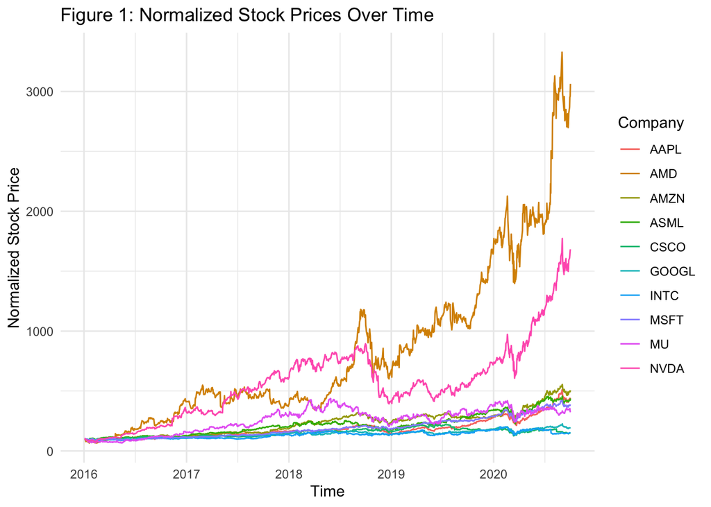

In Figure 1, we see a normalized stock plot of all ten companies between 2016 and 2020. Each stock price is normalized at a 100 dollars so we get a better look at the growth of different companies. We find that AMD and NVDA exhibit the largest growth, although all companies show some growth.

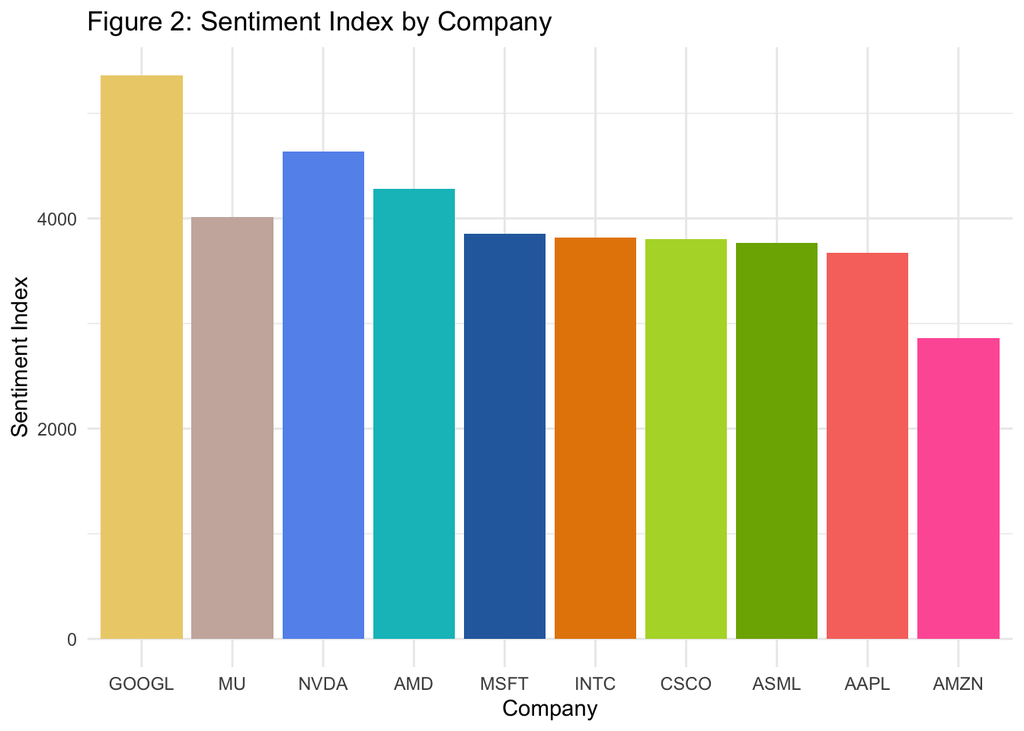

In Figure 2, we look at sentiment index of each company. This index is calculated by positive words minus negative words. We see that earnings calls primarily consist of positive words, with Google having the highest count.

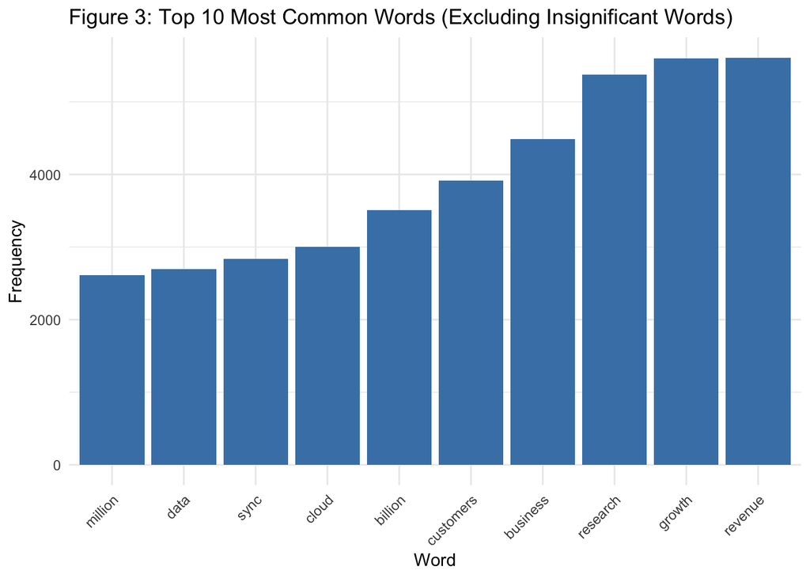

Figure 3 looks at most common words found in earnings calls. Excluded words include words like ceo, quarter, and call, which are insignificant to this analysis. Words such as revenue, growth, and costumers, all make sense to indicate a growing business to analysts and the public.

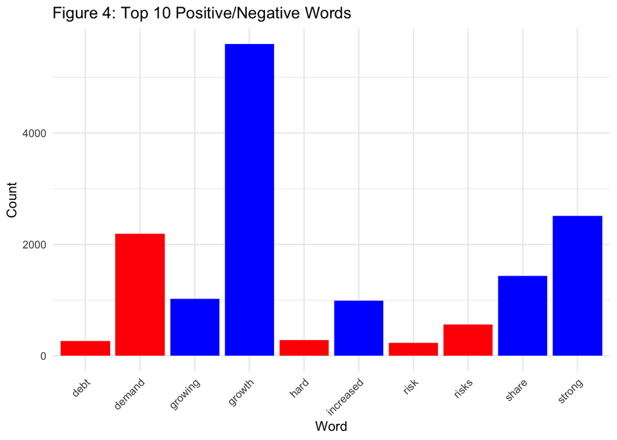

In Figure 4, a bar plot displays the five most common positive words, and 5 most common negative words. It is important to note that positive words are much more common than negative words, so these are not the ten most common words. One interesting point that this plot displays is that the most common negative words do not spark extremely negative emotions.

```
Table 1: Regression Analysis
================================================
                        Dependent variable:
                    ----------------------------
                               Close
------------------------------------------------
Positive                     -2.351***
                              (0.074)

Constant                    1,003.503***
                              (21.930)

------------------------------------------------
Observations                   11,758
R2                             0.079
Adjusted R2                    0.079
Residual Std. Error     516.964 (df = 11756)
F Statistic         1,003.487*** (df = 1; 11756)
================================================
Note:                *p<0.1; **p<0.05; ***p<0.01
```

In this regression analysis, we have the close stock price as the outcome variable and the positive sentiment as the explanatory variable. To further explain this regression, it looks at earnings call “x” in year “x” of company”x”. It then looks at the change in the stock price at the end of the current quarter from the end of the last quarter. This gives an accurate representation of how earnings calls sentiment may affect stock price. Here we see that they are significantly inversely correlated. This is an odd result, likely due to so many other factors more strongly affecting stock price. Also perhaps the stock price change is taken over too long of an interval for earnings calls sentiment to greatly affect it.

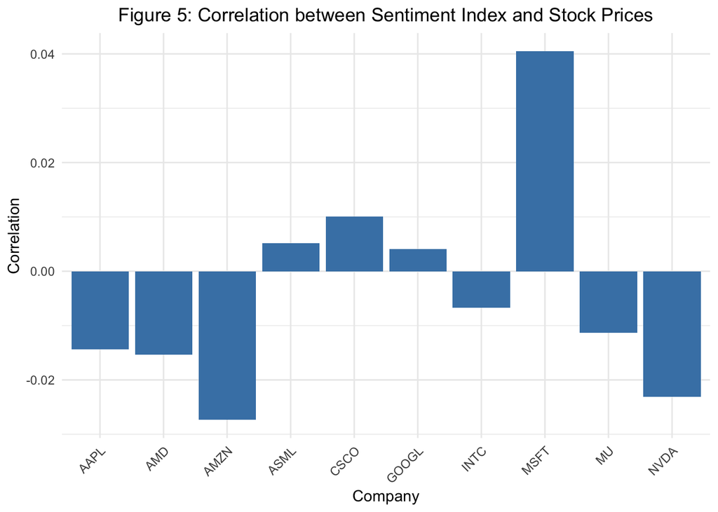

Figure 5 is a plot showing the correlation between sentiment and stock price. Once is again we see a mixed correlation likely due to reasons stated above. Microsoft has the highest correlation while Amazon has the least.

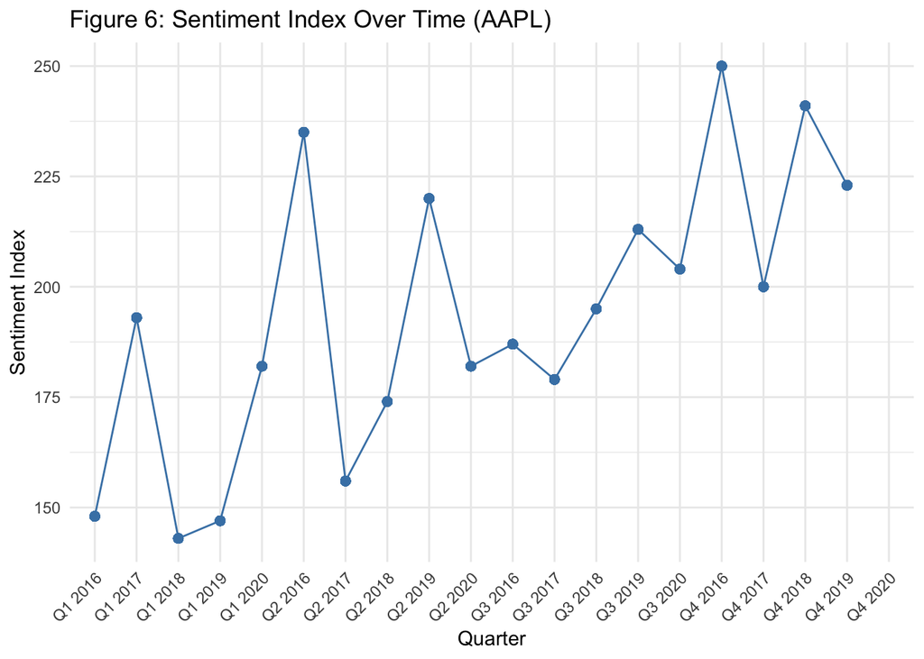

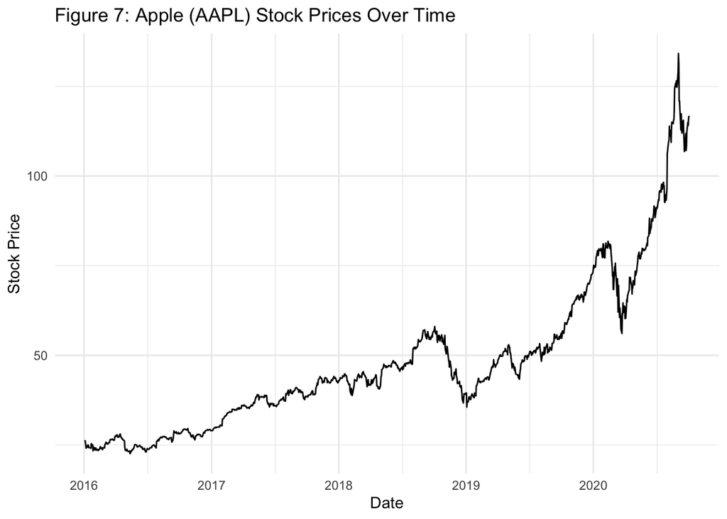

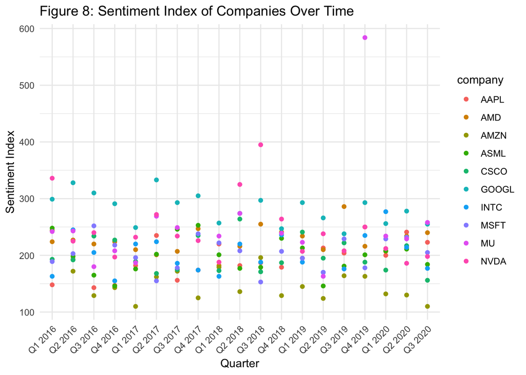

To conclude, this report provides insights regarding common words found in earnings calls, different positive and negative words, sentiment indexes, and preliminary analysis regarding effects of earnings calls sentiment on stock price. To conduct this analysis, transcripts and stock data is looked at for 2016-2020 of 10 of the most prominent companies. Originally, the hypothesis made was that a more positive sentiment would be positively correlated with stock price. The analysis conducted in this report shows otherwise. However, it is important to note that other factors such as supply and demand and consumer perception may be larger drivers affecting stock price. Thus, there is omitted variable bias. When re-visiting this analysis, looking at immediate change in stock price after the earnings call takes place will be insightful.